# Multiple layer measurements

Joan Ginard

27 de mayo, 2023

```r
library(igraph)
library(muxViz)
library(ggplot2)
source("helper_functions.R")
source("GraphMeasurementFunctions.R")
```

In this R markdown file, we will execute necessary steps to apply multi-layer graph measures to our data.

As in processing step we will use functions defined in “helper_functions.R”. We will also use functions defined in “GraphMeasurementFunctions.R”

# LOAD DATA

We proceed in a similar way to the single layer R markdown files

```r
#Folders
dataDIR <- "data/"
FADIR <- "FA_matrices_harm/"
GMDIR <- "GM_matrices_c/"
fMRIDIR <- "fMRI_matrices_c/"

### clinical data

clinic_file <- "clinic.csv"


### vertex names
names_file <- "mindboggle_ROIs.txt"
```

## Load clinical data

```r
clinical_data <- read.csv(file.path(dataDIR, clinic_file))[, -1] #with -1 we avoid loading index column

clinical_data <- clinical_data[order(clinical_data$id),] #order by id, though not necessay we enforce it
```

#### CREATE LABELS

```r
clinical_data$controls_ms <- factor(clinical_data$controls_ms,
                                    levels = c(0,1),
                                    labels = c("HS", "PwMS"))
clinical_data$sex <- factor(clinical_data$sex,
                            levels = c(0,1),
                            labels = c("Female", "Male"))
clinical_data$mstype <- factor(clinical_data$mstype,
                               levels = c(-1, 0, 1, 2),
                               labels = c("HS", "RRMS", "SPMS", "PPMS"))
```

## Load vertex names

```r
vertex_names <- read.table(file.path(dataDIR, names_file), skip = 1)[, 2]

# FA_vertex_names <- paste0("FA_", vertex_names)
# GM_vertex_names <- paste0("GM_", vertex_names)
# fMRI_vertex_names <- paste0("fMRI_", vertex_names)
# layered_vertex_names <- c(FA_vertex_names, GM_vertex_names, fMRI_vertex_names)
```

### Load matrices We import as matrix form, as we will need it for to build suparadjacency matrix in muxViz

```r
FA_matrices <- load_as_matrix(dataDIR, FADIR)
GM_matrices <- load_as_matrix(dataDIR, GMDIR)
fMRI_matrices <- load_as_matrix(dataDIR, fMRIDIR)
```

# SVD Normalization

We apply SVD normalization as explained in Mandke, Meier et al. 2018.

```r
FA_svd <- lapply(FA_matrices, svd_normalization)
GM_svd <- lapply(GM_matrices, svd_normalization)
fMRI_svd <- lapply(fMRI_matrices, svd_normalization)
```

# Multilayer graphs

In this case we will use a multiplex network where all nodes have self-connections and only self-connections across layers. It is important to to note we assume all layers are interconnected.

### Combine single layer graphs

Now we have 3 lists of matrices, one for each layer, and we need one list where each element is itself a list of three matrices one from each layer.

As we merge the lists, we calculate the mean of all connections across the three matrices. According to the literature (Mandke, Meier et al. 2018), we could utilize this mean as the connection weight between layers in a multiplex network.

```r
NodeTensor <- list()
NodeTensor_list <- list()
layerCouplingStrength_list <- list()
for(i in seq_along(FA_matrices)){
  NodeTensor<- list(FA_svd[[i]], GM_svd[[i]], fMRI_svd[[i]]) #Make list element combining on matrx from each layer
  NodeTensor_list[[i]] <- NodeTensor  # add element to a list

  all_values <- c(FA_svd[[i]], GM_svd[[i]], fMRI_svd[[i]])

  layerCouplingStrength_list[[i]] <- mean(all_values[all_values != 0]) #Mean of weights of the three layers.
}
```

Histogram of couplings strength, using the mean

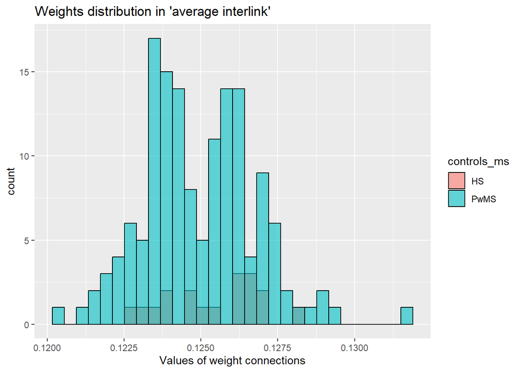

```r
x <- unlist(layerCouplingStrength_list)
x_df <- data.frame(values = x, controls_ms = clinical_data$controls_ms)

p <- ggplot(x_df, aes(x = values, fill = controls_ms)) +
  geom_histogram(position = "identity", bins = 30, color = "black", alpha = 0.6)+
  labs(x = "Values of weight connections", title = "Weights distribution in 'average interlink'")

ggsave(filename = "images/Mean_couplings_hist.png", plot = p, width = 10, height = 7, dpi = 300)
p
```

We observe that values are clustered between 0.12 and 0.1325. This suggests that differences are minimal (even when considering both HS and PwMS), and we can apply same weight to all subjects.

## Coupling strength value

We will assign different weights for interlayer connections and conduct statistical tests, similar to those performed on the single layers. We will record the number of measurements that pass these tests and select the multiplex network with the highest number of successful test results.

Multilayer measurements we will apply are all local as global measurement lead to no significant results.

Mutlilayer measurements are:

1. MultiPageRank centrality
2. Sum of total Multi-Strength, De Domenico, M., Set al. (2013)
3. Closeness Versatility (labeled as MultiPath)

Check which value of strength give us more diference between multilayer graphs measuments

```r
#Couplings we will test
couplings <- c(0.1, 0.2, 0.3, 0.4, 0.5, 0.6, 0.7, 0.8, 0.9, 1.0)


inter_layer_weight <- c()
length_stats <- c()
length_bonferroni <- c()
Layers <- 3
Nodes <- 76

# Iterate over a list of couplings
for(coupling in couplings){
  inter_layer_weight <- c(inter_layer_weight, coupling) #variable to keep track of couplings
  layerCouplingStrength <- coupling # Inter-layer weight links, we consider only multiplex connextion
  networkOfLayersType <- "categorical" #all layers are connected to each other

  layerTensor <- BuildLayersTensor(Layers=Layers, OmegaParameter=layerCouplingStrength, MultisliceType=networkOfLayersType)



  multilayer_graphs <- list()

  #Build multilayer graphs (via create a supra-adjacency matrix for each)
  for(i in seq_along(NodeTensor_list)){
    multilayer_graphs[[i]] <- BuildSupraAdjacencyMatrixFromEdgeColoredMatrices(NodeTensor_list[[i]],
                                                                             layerTensor,
                                                                             Layers,
                                                                             Nodes)
  }

  #Obtain multilayer local measures
  df <- clinical_data

  df <- add_multi_graph_measures(df, multilayer_graphs) # Function defined in GraphMeasurementFunctions.R



  cols <- colnames(df[, c(27:ncol(df))])
  vector_p <- c()
  for(col in cols){
    res <- statistical_test(df, col)
    vector_p <- c(vector_p, res)
  }
  stat_cols <- cols[vector_p < 0.05]


  length_stats <- c(length_stats, length(stat_cols))

  pairwise_t_tests_list <- lapply(stat_cols, function(x) {
    pairwise.t.test(df[[x]], df$mstype, p.adjust.method = "bonferroni")
  })

stat_cols_2 <- c()
for(i in seq_along(stat_cols)){
  p_values <- pairwise_t_tests_list[[i]]$p.value
  if(p_values[5] < 0.05 | p_values[6] < 0.05 | p_values[9] < 0.05){
    stat_cols_2 <- c(stat_cols_2, stat_cols[i])
  }
}
  length_bonferroni <- c(length_bonferroni, length(stat_cols_2))

}
```

Values collected are presented in following dataframe

```r
df_couplings <- data.frame(inter_layer_weight = inter_layer_weight,
                          statistical_significant = length_stats,
                          with_bonferroni = length_bonferroni)

df_couplings
```

```
##    inter_layer_weight statistical_significant with_bonferroni
## 1                 0.1                      28               3
## 2                 0.2                      29               4
## 3                 0.3                      29               4
## 4                 0.4                      29               4
## 5                 0.5                      29               4
## 6                 0.6                      31               4
## 7                 0.7                      31               4
## 8                 0.8                      31               4
## 9                 0.9                      31               4
## 10                1.0                      31               4
```

Before check which elements we have

## How many of each layer, how many of each measure and how many of each node

```r
split_names <- lapply(stat_cols, function(x) strsplit(x, split = "_")[[1]])

# Store each part in a separate vector
measure_vector <- sapply(split_names, `[[`, 1)
node_vector <- sapply(split_names, `[[`, 2)


table(measure_vector)
```

```
## measure_vector
##   MultiPath MultiPRCent  MultiSTSum
##           7          15           9
```

```r
head(sort(table(node_vector), decreasing = TRUE), n = 25)
```

```
## node_vector
##     Left-Accumbens-area    Right-Accumbens-area          ctx-rh-lingual
##                       3                       3                       2
##           Right-Caudate   Right-Thalamus-Proper ctx-lh-lateraloccipital
##                       2                       2                       1
##          ctx-lh-lingual   ctx-lh-middletemporal    ctx-lh-pericalcarine
##                       1                       1                       1
##       ctx-lh-precentral        ctx-lh-precuneus    ctx-lh-supramarginal
##                       1                       1                       1
## ctx-rh-inferiorparietal ctx-rh-lateraloccipital       ctx-rh-precentral
##                       1                       1                       1
##  ctx-rh-superiorfrontal ctx-rh-superiorparietal ctx-rh-superiortemporal
##                       1                       1                       1
##           Left-Amygdala            Left-Caudate        Left-Hippocampus
##                       1                       1                       1
##            Left-Putamen    Left-Thalamus-Proper           Right-Putamen
##                       1                       1                       1
```

```r
print(stat_cols_2)
```

```
## [1] "MultiPRCent_ctx-lh-precentral"       "MultiPRCent_Left-Accumbens-area"
## [3] "MultiPRCent_ctx-rh-lateraloccipital" "MultiSTSum_ctx-rh-superiorfrontal"
```

In next step we will check if we have correlations between those measurement

```r
library(tidyverse)
```

[figure not shown]

```r
multi_layer_df <- cbind(clinical_data[, c("id", "controls_ms", "mstype", "age", "sex", "dd", "edss")],
                             df[ , stat_cols])

correlations <- multi_layer_df %>% select(all_of(stat_cols)) %>% cor()

corrplot::corrplot(correlations, method = 'number', tl.col = "black", addCoef.col = 1,
         number.cex = 0.9, tl.cex = 1.3)
```

*save image*

```r
png("images/corr_mult_layers_local.png")
corrplot::corrplot(correlations, tl.col = "black",  tl.cex = 0.8)
dev.off()
```

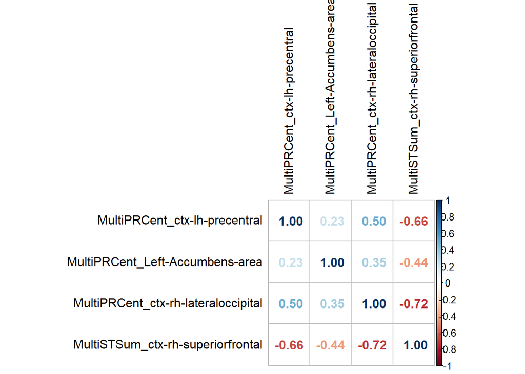

```r
multi_layer_df <- cbind(clinical_data[, c("id", "controls_ms", "mstype", "age", "sex", "dd", "edss")],
                             df[ , stat_cols])

correlations <- multi_layer_df %>% select(all_of(stat_cols_2)) %>% cor()

corrplot::corrplot(correlations, method = 'number', tl.col = "black")
```

*save image*

```r
png("images/corr_mult_layers_local_bonf.png")
corrplot::corrplot(correlations, method = 'number', tl.col = "black")
dev.off()
```

```r
write.table(multi_layer_df, file = file.path(dataDIR, "multi_layer.csv"), sep = ",", quote = FALSE, row.names = FALSE )
```

Summarise Results

```r
#Preserve only numerical values
df_temp <- cbind(df[, "controls_ms"], df[, 27:ncol(df)])
colnames(df_temp)[1] <- "controls_ms"

df_summary <- data.frame(measurement = character(0),
                          Mean_HS = numeric(0),
                         sd_HS = numeric(0),
                         Mean_PWMS = numeric(0),
                         sd_PWMS = numeric(0))

for(i in 2:ncol(df_temp)){
  measurement <- colnames(df_temp)[i]
  Mean_HS <- mean(df_temp[df_temp$controls_ms == "HS", i])
  sd_HS <- sd(df_temp[df_temp$controls_ms == "HS", i])

  Mean_PWMS <- mean(df_temp[df_temp$controls_ms == "PwMS", i])
  sd_PWMS <- sd(df_temp[df_temp$controls_ms == "PwMS", i])

  df_summary <- rbind( df_summary, data.frame(measurement = measurement,
                                              Mean_HS = Mean_HS,
                                              sd_HS = sd_HS,
                                              Mean_PWMS = Mean_PWMS,
                                              sd_PWMS = sd_PWMS))

}

df_summary$p.values <- vector_p
```

## SAVE SUMMARY TO EXCEL

```r
wb <- openxlsx::createWorkbook()


openxlsx::addWorksheet(wb, "multilayer_meas")
openxlsx::writeData(wb, "multilayer_meas", df_summary)

openxlsx::saveWorkbook(wb, file = paste0(dataDIR, "summary_multi_layer.xlsx"), overwrite = TRUE)
```